# Final_Project_Zahn

```r
library(ape)
library(phangorn)
```

### Mammalian mito genomes:

## Link to Andrew Gibson’s 2005 paper, “A Comprehensive Analysis of Mammalian Mitochondrial # Genome Base Composition and Improved Phylogenetic Methods”:

# https://academic.oup.com/mbe/article/22/2/251/963859

## First, I read in the taxanomic info and DNA sequences:

```r
mamm.taxa = read.table("/Users/jamescutler/Desktop/APER2_Online_Material/mammal_mtGenome.fasta",
                          skip = 4, nrows = 233, sep = "_", comment.char = "(", as.is = TRUE) # HOW TO MAKE SENSE OF ALL THIS GIBBERISH??
mamm.taxa[1:5,]
```

```
##              V1                    V2 V3
## 1 #ORYCUNMIT :  Oryctolagus cuniculus NA
## 2 #OCHPRIMIT :      Ochotona princeps NA
## 3 #OCHCOLMIT :      Ochotona collaris NA
## 4 #LEPEURMIT :        Lepus europaeus NA
## 5 #EREGRAMIT :      Eremitalpa granti NA
```

```r
mamm.taxa$V3 = NULL
mamm.taxa$V1 = gsub("#", "", mamm.taxa$V1)
mamm.taxa$V1 = gsub(" : ", "", mamm.taxa$V1)
colnames(mamm.taxa) = c("code","species")

mito.DNA = read.dna("/Users/jamescutler/Desktop/APER2_Online_Material/mammal_mtGenome.fasta",
                   format = "fasta", skip = 239)
# WHY THE SKIP = 239????
```

# Preliminary exploration:

```r
length(mito.DNA)
```

```
## [1] 9087
```

```r
class(mito.DNA)
```

```
## [1] "DNAbin"
```

```r
names(mito.DNA)[1:10]
```

```
##  [1] "ORYCUNMIT(ATP6)" "OCHPRIMIT(ATP6)" "OCHCOLMIT(ATP6)"
##  [4] "LEPEURMIT(ATP6)" "EREGRAMIT(ATP6)" "PONBLAMIT(ATP6)"
##  [7] "CAPHIRMIT(ATP6)" "MONMONMIT(ATP6)" "BALOMUMIT(ATP6)"
## [10] "CAPMARMIT(ATP6)"
```

## I would like to create gene names, because this database includes dozens of mito genes for these mammals:

```r
gene.names = gsub("^[[:alnum:]]{1,}\\(","",names(mito.DNA)); gene.names[1:10]
```

```
##  [1] "ATP6)" "ATP6)" "ATP6)" "ATP6)" "ATP6)" "ATP6)" "ATP6)" "ATP6)"
##  [9] "ATP6)" "ATP6)"
```

```r
gene.names = gsub("\\)$","",gene.names)
length(names(mito.DNA))
```

```
## [1] 9087
```

```r
unique(gene.names)
```

```
##  [1] "ATP6"
##  [2] "ATP8"
##  [3] "COX1"
##  [4] "COX2"
##  [5] "COX3"
##  [6] "CYTB"
##  [7] "ND1"
##  [8] "ND2"
##  [9] "ND3"
## [10] "ND4"
## [11] "ND4L"
## [12] "ND5"
## [13] "ND6"
## [14] "RNL"
## [15] "RNL)Sequence does not exist"
```

[output cut: 45 more lines]

```r
length(unique(gene.names)) # only 60 different genes (only 39 of which have 233 homologues)
```

```
## [1] 60
```

## This is not a totally cleaned up dataset. I’m going to get rid of some stuff I don’t want:

```r
i = grep("Sequence does not exist", names(mito.DNA)); str(i)
```

```
##  int [1:519] 3137 4149 4382 4615 4848 5081 5547 5780 5826 5827 ...
```

```r
mito.DNA = mito.DNA[-i]; length(mito.DNA) # REALLY IMPORTANT CODE--THIS IS HOW YOU TRIM A DATAFRAME (OR DNAbin)
```

```
## [1] 8568
```

```r
9087-8568 # 519 rows were removed
```

```
## [1] 519
```

## Okay, now there are fewer mito.DNA rows–fewer names. If I do the gene.names code over again, I’ll get a different (smaller) set of gene names:

```r
gene.names = gsub("^[[:alnum:]]{1,}\\(","",names(mito.DNA))
gene.names = gsub("\\)$","",gene.names); length(unique(gene.names))
```

```
## [1] 39
```

## Now there are 39 unique gene names.

```r
table(gene.names) # "table" is a cool function
```

```
## gene.names
##          ATP6          ATP8          COX1          COX2          COX3
##           233           233           233           233           233
##          CYTB           ND1           ND2           ND3           ND4
##           233           233           233           233           233
##          ND4L           ND5           ND6           RNL           RNS
##           233           233           233           232           233
##      tRNA-Ala      tRNA-Arg      tRNA-Asn      tRNA-Asp      tRNA-Cys
##           233           233           232           232           232
##      tRNA-Gln      tRNA-Glu      tRNA-Gly      tRNA-His      tRNA-Ile
##           232           232           233           232           232
##      tRNA-Leu tRNA-Leu(CUN) tRNA-Leu(UUR)      tRNA-Lys      tRNA-Met
##            16           217           217           232           232
##      tRNA-Phe      tRNA-Pro      tRNA-Ser tRNA-Ser(AGY) tRNA-Ser(UCN)
##           230           227            17           216           218
##      tRNA-Thr      tRNA-Trp      tRNA-Tyr      tRNA-Val
##           232           232           232           233
```

```r
sum(table(gene.names)) # should be 8568, and it is!
```

```
## [1] 8568
```

## What I would like to do is create a phylogeny–a gene tree for a specific mito gene–of some subset of the 233 mammalian species–of mammals I’m particularly interested in.

# I could pick the gene Cox1, or ATP6, or any gene from among the list of 39 or so in this database.

# I could do multiple gene trees and see whether and how any of them differ.

# Before creating a phylogeny, though, I’ll start out by simply analyzing base frequency:

# We can analyze base frequencies at three levels of variation:

## Between species (all genes pooled)

## Between genes (all species pooled)

## Between sites for a single protein-coding gene (all species pooled)

# First, between species (with all genes pooled):

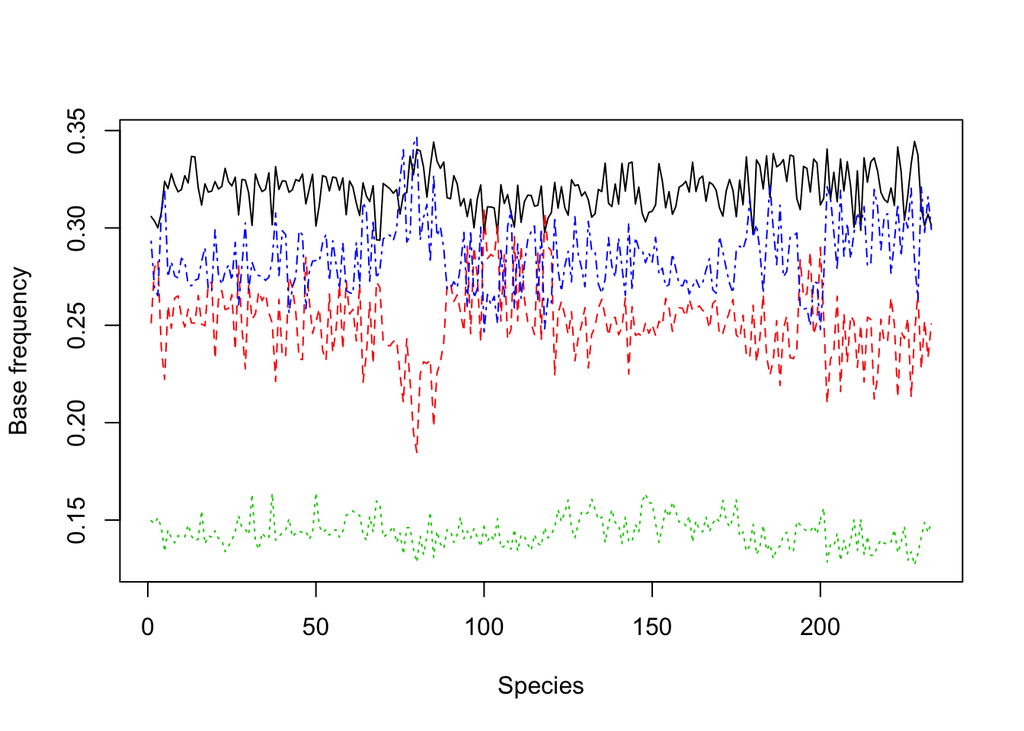

```r
BF.b_sp = matrix(NA, nrow = 233, ncol = 4)
rownames(BF.b_sp) = mamm.taxa$species
colnames(BF.b_sp) = c("A","C","G","T")
for (i in 1:233){
  x = grep(mamm.taxa$code[i], names(mito.DNA))
  BF.b_sp[i,] = base.freq(mito.DNA[x])
}
matplot(BF.b_sp, type = "l", col = 1:4, xlab = "Species",
        ylab = "Base frequency")
```

# The other analysis I’ll show here is between genes (with all species pooled):

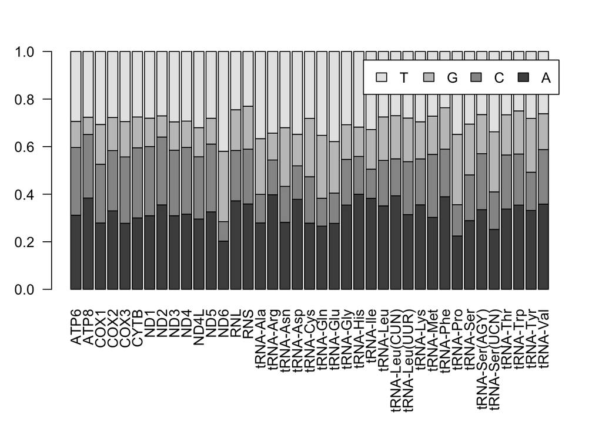

```r
BF.gene = matrix(NA, nrow = 39, ncol = 4)
rownames(BF.gene) = unique(gene.names)
colnames(BF.gene) = c("A","C","G","T")
for (i in 1:nrow(BF.gene)){
  x = grep(rownames(BF.gene)[i], names(mito.DNA), fixed = TRUE)
  BF.gene[i,] = base.freq(mito.DNA[x])
}
par(mar = c(8,3,3,2))
barplot(t(BF.gene), las = 2, legend = TRUE,
        args.legend = list(horiz = TRUE, bg = "white"))
```

```r
dev.off()
```

# What I’m interested in regarding each specific gene is the gene tree, again, only including a particular subset of all 233 (233 tips would be too massive a tree for me to meaningfully digest or to legibly display in a single plot).

# Here is one list I came up with, totaling about 50, of mammals whose Cox1 gene tree I’m curious about (I picked Cox1 just because it’s sort of familiar):

## Pontoporia blainvillei - La Plata dolphin

## Lagenorhynchus albirostris - white-beaked dolphin

## Balaenoptera omurai - Omura’s whale

## Caperea marginata - pygmy right whale

## Balaenoptera edeni - Bryde’s whale

## Monodon monoceros - narwhal

## Kogia breviceps - pygmy sperm whale

## Halichoerus grypus - grey seal

## Phoca largha - spotted seal

## Oryctolagus cuniculus - European rabbit

## Lepus europaeus - European hare

## Cavia porcellus - guinea pig

## Mus musculus - house mouse

## Rattus norvegicus - brown rat

## Jaculus jaculus - lesser Egyptian jerboa (rodent)

## Lemur catta - ring-tailed lemur

## Tarsius bancanus - Horsfield’s tarsier

## Semnopithecus entellus - northern plains gray langur (Old World)

## Macaca mulatta - rhesus macaque

## Pongo pygmaeus - Bornean orangutan

## Gorilla gorilla

## Pan paniscus - bonobo

## Homo sapiens

## Ursus arctos - brown bear

## Canis lupus - gray wolf

## Gulo gulo - wolverine

## Procyon lotor - raccoon

## Panthera pardus - leopard

## Felis catus - domestic cat

## Bos taurus - cow

## Bubalus bubalis - water buffalo

## Camelus dromedarius - dromedary

## Lama pacos - alpaca

## Equus asinus - donkey

## Equus caballus

## Elaphodus cephalophus - tufted deer

## Pantholops hodgsonii - Tibetan antelope

## Cervus nippon yesoensis - Yezo Sika deer (Japan)

## Ovis aries - sheep

## Ammotragus lervia - Barbary sheep

## Capra hircus - goat

## Sus scrofa - wild boar

## Phacochoerus africanus - common warthog

## Macroscelides proboscideus - round-eared elephant shrew

## Loxodonta africana - African elephant

## Dugong dugon

## Hippopotamus amphibius

## Manis tetradactyla - long-tailed pangolin

## Pteropus scapulatus - little red flying fox

## Zaglossus bruijni - western long-beaked echidna

## Ornithorhynchus anatinus - platypus

## Phascolarctos cinereus - koala

## Lagostrophus fasciatus - banded-hare wallaby

## Here’s how I chose to subset the data and just look at those ~50 animals:

```r
y = c(6,17,9,10,15,8,27,174,142,1,4,193,192,187,180,117,110,115,120,118,97,119,109,175,140,
      166,128,124,172,28,12,31,16,90,89,29,32,26,11,36,7,13,14,176,72,68,42,121,60,233,232,228,205)
mamm.taxa$code[y]
```

```
##  [1] "PONBLAMIT" "LAGALBMIT" "BALOMUMIT" "CAPMARMIT" "BALEDEMIT"
##  [6] "MONMONMIT" "KOGBREMIT" "HALGRYMIT" "PHOLARMIT" "ORYCUNMIT"
## [11] "LEPEURMIT" "CAVPORMIT" "MUSMUSMIT" "RATNORMIT" "JACJACMIT"
## [16] "LEMCATMIT" "TARBANMIT" "SEMENTMIT" "MACMULMIT" "PONPYGMIT"
## [21] "GORGORMIT" "PANPANMIT" "HOMSAPMIT" "URSARCMIT" "CANLUPMIT"
## [26] "GULGULMIT" "PROLOTMIT" "PANPARMIT" "FELCATMIT" "BOSTAUMIT"
## [31] "BUBBUBMIT" "CAMDROMIT" "LAMPACMIT" "EQUASIMIT" "EQUCABMIT"
## [36] "ELACEPMIT" "PANHODMIT" "NIPYESMIT" "OVIARIMIT" "AMMLERMIT"
## [41] "CAPHIRMIT" "SUSSCRMIT" "PHAAFRMIT" "MACPROMIT" "LOXAFRMIT"
## [46] "DUGDUGMIT" "HIPAMPMIT" "MANTETMIT" "PTESCAMIT" "ZAGBRUMIT"
## [51] "ORNANAMIT" "PHACINMIT" "LAGFASMIT"
```

```r
cox1 = mito.DNA[grep("COX1", names(mito.DNA))]
cox1 = cox1[y]
common.names = data.frame(scientific = mamm.taxa$species[y],
                          common = c("La Plata dolphin","white-beaked dolphin","Omura's whale","pygmy right whale",
                                     "Bryde's whale","narwhal","pygmy sperm whale","grey seal","spotted seal",
                                     "European rabbit","European hare","guinea pig","house mouse","brown rat",
                                     "lesser Egyptian jerboa","ring-tailed lemur","Horsfield's tarsier","northern plains gray langur",
                                     "rhesus macaque","Bornean orangutan","gorilla","bonobo","us","brown bear","gray wolf","wolverine",
                                     "raccoon","leopard","domestic cat","cow","water buffalo","dromedary","alpaca","donkey","horse",
                                     "tufted deer","Tibetan antelope","Yezo Sika deer","sheep","Barbary sheep","goat","wild boar",
                                     "common warthog","round-eared elephant shrew","African elephant","dugong","hippo","long-tailed pangolin",
                                     "little red flying fox","western long-beaked echidna","platypus","koala","banded-hare wallaby"))
names(cox1) = common.names$common
```

## This is code I’m not going to run, cuz it takes several minutes:

```r
# cox1.53.clus = clustal(cox1) # Less than 5 minutes to compute
# setwd("/Users/jamescutler/Desktop/Data_Course_cutler/")
# save(cox1.clus, file = "Cox1_53_clus_common_names.RData")
```

## Instead, I’ll just load the presaved clustal alignment I have from running the alignment earlier:

```r
load("/Users/jamescutler/Desktop/Data_Course_cutler/Cox1_53_clus_common_names.RData")
```

# And image it:

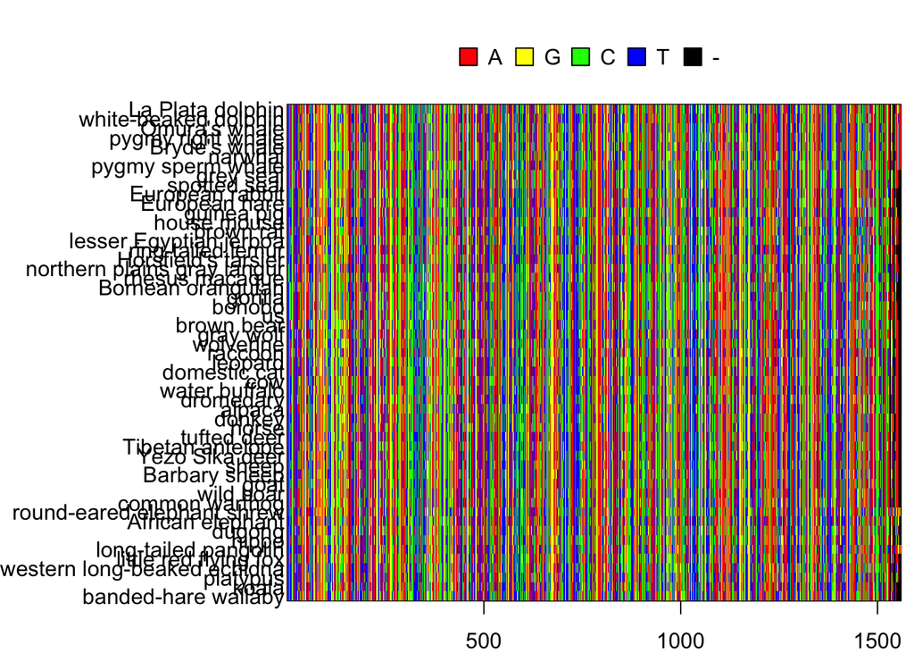

```r
par(mar=c(2,11,4,.5))
image(cox1.53.clus)
```

```r
dev.off()
```

# And finally plot the phylogenetic tree (using neighbor-joining):

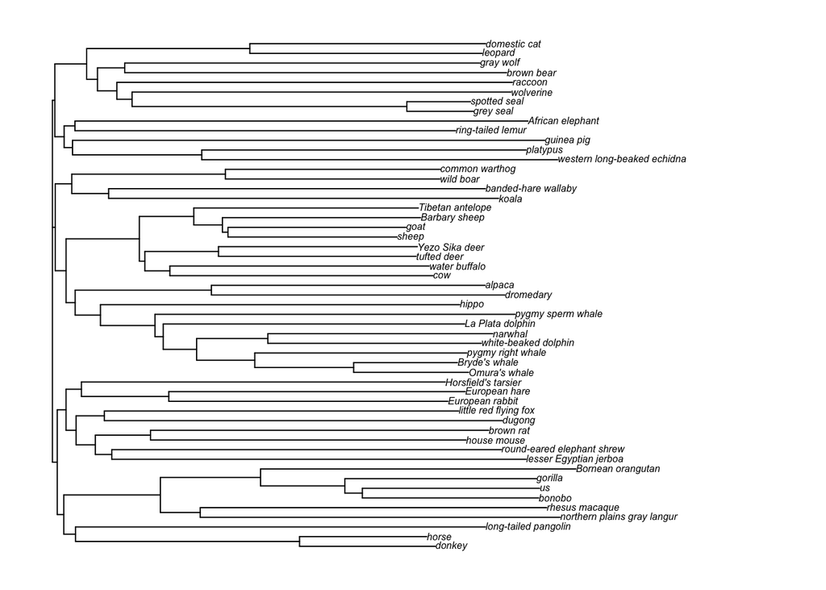

```r
d.cox1 = dist.dna(cox1.53.clus)
tr.nj.cox1 = nj(d.cox1)
par(mar=c(1,1,1,1))
plot(tr.nj.cox1, cex = .5)
```

## Now for maximum likelihood with UPGMA (unweighted pair group method with arithmetic mean):

```r
class(cox1.53.clus)
```

```
## [1] "DNAbin"
```

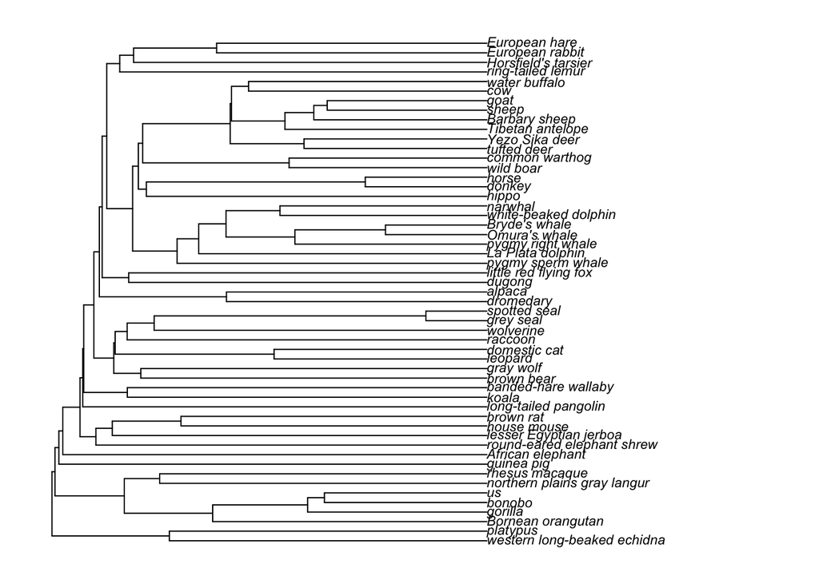

```r
cox1.phydat = as.phyDat(cox1.53.clus)
dml.cox1 = dist.ml(cox1.phydat)
trUPGMA.cox1 = upgma(dml.cox1)
par(mar=c(1,1,1,1))
plot(trUPGMA.cox1, cex = .7)
```

## Now for some cool things you can do with trees:

# Using a woodmouse phylogeny as an example:

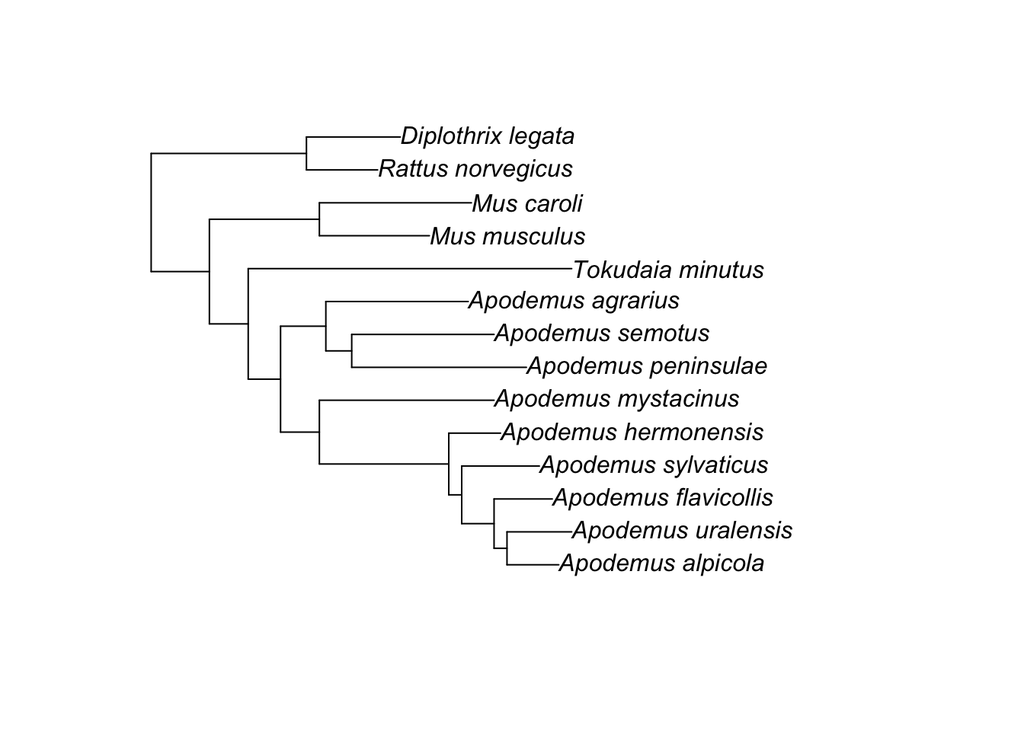

```r
wm.tre = read.tree("/Users/jamescutler/Desktop/APER2_Online_Material/rodent.tre")
plot(wm.tre)
```

```r
wm.tre$edge.length
```

```
##  [1] 0.012857 0.008571 0.007143 0.008571 0.028571 0.002857 0.007143
##  [8] 0.002857 0.011429 0.014286 0.012857 0.017143 0.011429 0.038571
## [15] 0.010000 0.005714 0.038571 0.031429 0.031429 0.071429 0.024286
## [22] 0.024286 0.033571 0.034286 0.015714 0.020714
```

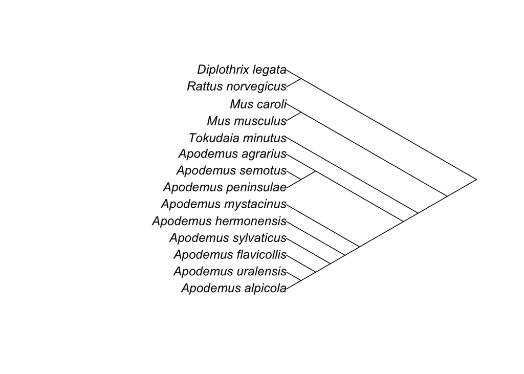

```r
plot(wm.tre, type = "c", use.edge.length = FALSE, direction = "l")
```

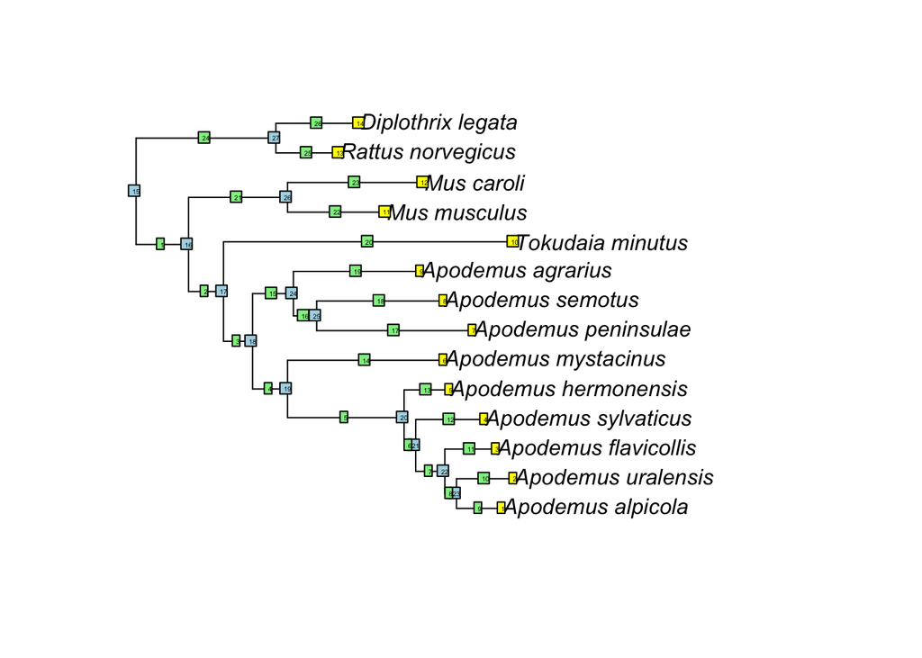

```r
plot(wm.tre); nodelabels(cex = .3); tiplabels(cex = .3); edgelabels(cex = .3)
```

# My favorite method for visualizing bootstrap values for the nodes:

```r
bs.ml = c(NA,88,76,73,71,100,45,81,72,67,63,100,100)
plot(wm.tre, no.margin = TRUE)
nodelabels(bs.ml, adj = c(1.2, -.5), frame = "n",
           cex = .8, font = 2)
c.code = c("black","grey","white")
p = character(length(bs.ml))
p[bs.ml >= 90] = c.code[1]
p[bs.ml < 90 & bs.ml >= 70] = c.code[2]
p[bs.ml < 70] = c.code[3]
p
```

```
##  [1] ""      "grey"  "grey"  "grey"  "grey"  "black" "white" "grey"
##  [9] "grey"  "white" "white" "black" "black"
```

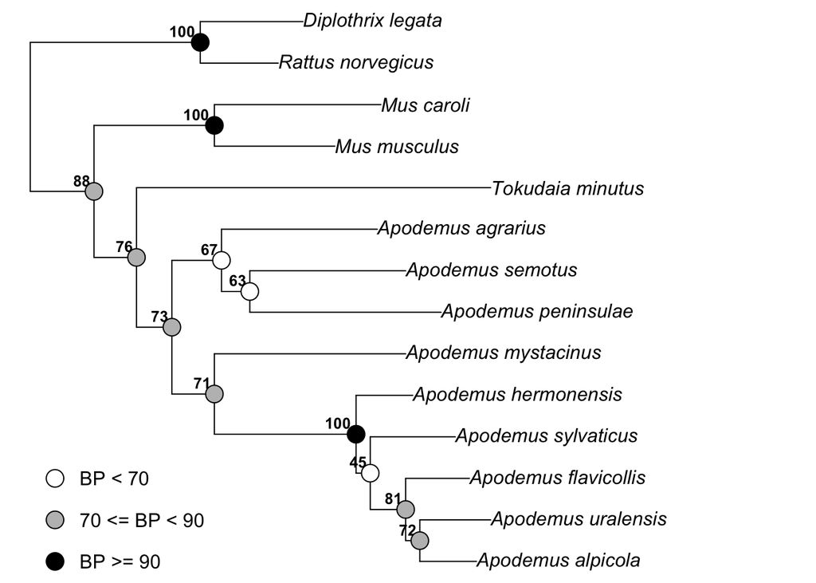

```r
nodelabels(node = 16:27, pch = 21, bg = p[-1], cex = 2)
points(rep(.005,3), 1:3, pch = 21, cex = 2, bg = c.code)
text(rep(.01,3), 1:3, adj = 0, c("BP >= 90","70 <= BP < 90","BP < 70"))
```

# Now without the numbers (just the colors):

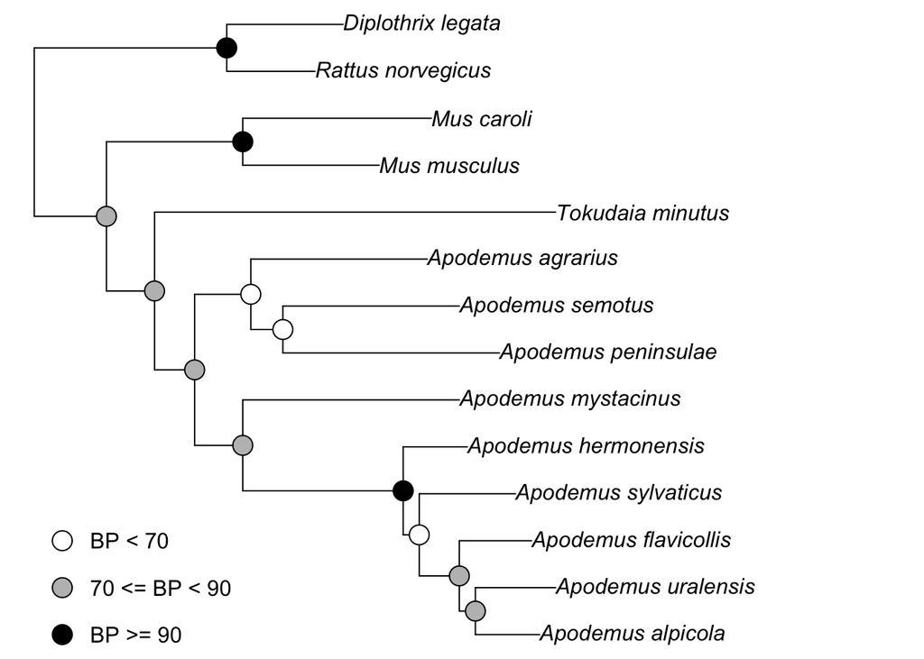

```r
plot(wm.tre, no.margin = TRUE)
nodelabels(node = 16:27, pch = 21, bg = p[-1], cex = 2)
points(rep(.005,3), 1:3, pch = 21, cex = 2, bg = c.code)
text(rep(.01,3), 1:3, adj = 0, c("BP >= 90","70 <= BP < 90","BP < 70"))
```